# Análisis Predictivo en Business Intelligence: segmentación (cluster) en R

Autor/a

Fernando Salcedo Mejía Eco, Ms

Fecha de publicación

1 de febrero de 2026

Este notebook desarrolla en R el caso de segmentación de la presentación **Análisis Predictivo en Business Intelligence**.

Las funciones principales que usamos son:

| Función | Paquete | Para qué sirve |
| --- | --- | --- |
| `scale()` | `base` (R base) | Estandarizar las variables |
| `kmeans()` | `stats` (R base) | Estimar los grupos con k-means |
| `silhouette()` | `cluster` | Calcular el coeficiente de silueta |
| `+`, `plot_layout()` | `patchwork` | Combinar varios gráficos de ggplot en una sola figura |

```r
library(tidyverse)
library(cluster)
library(patchwork)

theme_set(theme_minimal(base_size = 13))
options(digits = 3) # mostrar los resultados con 3 decimales
```

# 1 Segmentación de clientes (RFM)

El área de marketing de una cadena de retail quiere diseñar acciones diferenciadas según el comportamiento de compra de sus clientes: **recencia**, **frecuencia** y **ticket promedio**.

## 1.1 Datos

| Variable | Descripción |
| --- | --- |
| `id_cliente` | Número único del cliente |
| `recencia` | Días desde la última compra (menor es mejor) |
| `frecuencia` | Número de compras en el último año |
| `ticket_promedio` | Valor promedio de cada compra (USD) |

```r
retail <- read_csv("datos/retail_rfm.csv", show_col_types = FALSE)

summary(select(retail, -id_cliente))
```

```
    recencia       frecuencia   ticket_promedio
 Min.   :  1.0   Min.   : 1.0   Min.   : 13.3
 1st Qu.: 27.0   1st Qu.: 3.0   1st Qu.: 44.5
 Median : 50.0   Median : 8.0   Median : 62.3
 Mean   : 94.2   Mean   :10.2   Mean   : 87.9
 3rd Qu.:150.0   3rd Qu.:15.0   3rd Qu.:127.2
 Max.   :365.0   Max.   :40.0   Max.   :293.3
```

## 1.2 Estandarización

$$z = \frac{x - \bar{x}}{s}$$

`scale()` aplica esta transformación a cada columna:

```r
variables_rfm <- c("recencia", "frecuencia", "ticket_promedio")

X_rfm <- scale(retail[variables_rfm])

head(X_rfm)
```

```
     recencia frecuencia ticket_promedio
[1,]  -0.4339     -0.400           0.794
[2,]   0.8513     -1.018          -0.761
[3,]  -0.0336     -0.523           2.877
[4,]  -0.1600     -1.018           1.183
[5,]  -0.9817      0.590          -0.581
[6,]  -0.8974      2.074           0.195
```

## 1.3 Elegir el número de grupos

Se estima k-means para $k = 2, \dots, 8$ grupos. Para cada $k$ se guardan dos medidas:

- **Inercia** (`tot.withinss`): la suma de las distancias al cuadrado de cada cliente a su centroide. Siempre baja al aumentar $k$; se busca el **codo**, el punto a partir del cual deja de bajar mucho.
- **Silueta promedio**: mide qué tan bien separado está cada cliente de los demás grupos. Va de -1 a 1; cuanto más alta, mejor.

`nstart = 10` indica que k-means se ejecuta 10 veces con centroides iniciales distintos y se queda con la mejor solución.

```r
k_valores <- 2:8
inercia <- numeric(length(k_valores))
silueta <- numeric(length(k_valores))

distancias <- dist(X_rfm) # distancias entre todos los clientes, para la silueta

set.seed(2026)
for (i in seq_along(k_valores)) {
  modelo <- kmeans(X_rfm, centers = k_valores[i], nstart = 10)
  inercia[i] <- modelo$tot.withinss
  silueta[i] <- mean(silhouette(modelo$cluster, distancias)[, "sil_width"])
}

seleccion_k <- tibble(k = k_valores, inercia = inercia, silueta = silueta)
seleccion_k
```

| k | inercia | silueta |
| --- | --- | --- |
| 2 | 3182 | 0.481 |
| 3 | 1620 | 0.584 |
| 4 | 872 | 0.610 |
| 5 | 662 | 0.569 |
| 6 | 568 | 0.520 |
| 7 | 480 | 0.417 |
| 8 | 430 | 0.402 |

Cada gráfico se guarda en un objeto y, con el paquete `patchwork`, se combinan en una sola figura sumándolos con `+`:

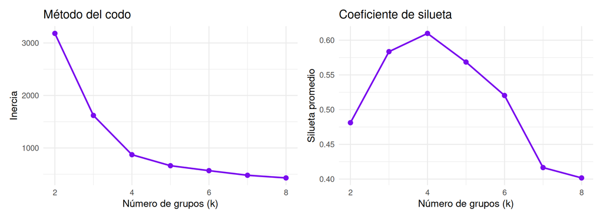

```r
g_codo <- ggplot(seleccion_k, aes(k, inercia)) +
  geom_line(color = "#790cee", linewidth = 1) +
  geom_point(color = "#790cee", size = 2.5) +
  labs(title = "Método del codo", x = "Número de grupos (k)", y = "Inercia")

g_silueta <- ggplot(seleccion_k, aes(k, silueta)) +
  geom_line(color = "#790cee", linewidth = 1) +
  geom_point(color = "#790cee", size = 2.5) +
  labs(
    title = "Coeficiente de silueta",
    x = "Número de grupos (k)",
    y = "Silueta promedio"
  )

g_codo + g_silueta
```

```r
k_optimo <- k_valores[which.max(silueta)]
```

El codo aparece en $k = 4$, que también es el valor con la silueta más alta.

## 1.4 Estimación y perfil de los segmentos

Se estima k-means con 4 grupos y se guarda en `retail` el grupo asignado a cada cliente.

```r
set.seed(2026)
kmeans_rfm <- kmeans(X_rfm, centers = k_optimo, nstart = 10)

retail$grupo <- kmeans_rfm$cluster
```

El **perfil** de cada grupo es el promedio de sus variables en las unidades originales (días, compras y USD), que son más fáciles de interpretar que las estandarizadas:

```r
perfil <- retail |>
  group_by(grupo) |>
  summarise(
    recencia = mean(recencia),
    frecuencia = mean(frecuencia),
    ticket_promedio = mean(ticket_promedio),
    clientes = n()
  ) |>
  mutate(pct_clientes = clientes / sum(clientes) * 100) |>
  arrange(recencia)

perfil
```

| grupo | recencia | frecuencia | ticket_promedio | clientes | pct_clientes |
| --- | --- | --- | --- | --- | --- |
| 3 | 10.6 | 25.23 | 121.4 | 295 | 14.8 |
| 2 | 36.3 | 12.56 | 60.1 | 745 | 37.2 |
| 4 | 71.7 | 5.16 | 184.7 | 393 | 19.6 |
| 1 | 229.3 | 2.88 | 39.7 | 567 | 28.4 |

k-means numera los grupos al azar (1, 2, 3, 4), así que el número no tiene significado. Para darles un nombre, los grupos se ordenaron por recencia, del que compró más recientemente al que lleva más tiempo sin comprar, y se nombran según su perfil:

```r
perfil$segmento <- c(
  "Campeones",
  "Leales",
  "Ocasionales de alto ticket",
  "Inactivos"
)

retail <- left_join(retail, select(perfil, grupo, segmento), by = "grupo")

# Factor para que los gráficos muestren los segmentos en este orden y no alfabéticamente
retail$segmento <- factor(retail$segmento, levels = perfil$segmento)

select(
  perfil,
  segmento,
  recencia,
  frecuencia,
  ticket_promedio,
  clientes,
  pct_clientes
)
```

| segmento | recencia | frecuencia | ticket_promedio | clientes | pct_clientes |
| --- | --- | --- | --- | --- | --- |
| Campeones | 10.6 | 25.23 | 121.4 | 295 | 14.8 |
| Leales | 36.3 | 12.56 | 60.1 | 745 | 37.2 |
| Ocasionales de alto ticket | 71.7 | 5.16 | 184.7 | 393 | 19.6 |
| Inactivos | 229.3 | 2.88 | 39.7 | 567 | 28.4 |

## 1.5 Visualización de los segmentos

Los dos gráficos usan los mismos colores, así que con `plot_layout(guides = "collect")` se muestra **una sola leyenda** para ambos:

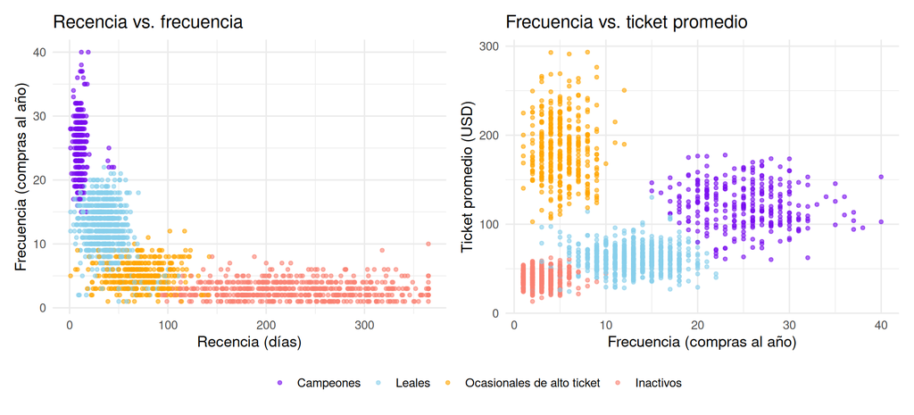

```r
colores <- c(
  "Campeones" = "#790cee",
  "Leales" = "skyblue",
  "Ocasionales de alto ticket" = "orange",
  "Inactivos" = "salmon"
)

g_recencia <- ggplot(retail, aes(recencia, frecuencia, color = segmento)) +
  geom_point(size = 1.2, alpha = 0.6) +
  scale_color_manual(values = colores) +
  labs(
    title = "Recencia vs. frecuencia",
    x = "Recencia (días)",
    y = "Frecuencia (compras al año)",
    color = NULL
  )

g_ticket <- ggplot(retail, aes(frecuencia, ticket_promedio, color = segmento)) +
  geom_point(size = 1.2, alpha = 0.6) +
  scale_color_manual(values = colores) +
  labs(
    title = "Frecuencia vs. ticket promedio",
    x = "Frecuencia (compras al año)",
    y = "Ticket promedio (USD)",
    color = NULL
  )

g_recencia +
  g_ticket +
  plot_layout(guides = "collect") &
  theme(legend.position = "bottom")
```

El símbolo `&` aplica `theme(legend.position = "bottom")` a toda la figura combinada, para ubicar la leyenda compartida debajo de los dos gráficos.

## 1.6 Asignar un cliente nuevo

Cuando llega un cliente nuevo, se asigna al segmento cuyo **centroide** está más cerca. Hay que hacerlo en dos pasos:

1. **Estandarizar** al cliente nuevo con la media y la desviación de los datos originales (no con las suyas).
2. Calcular su **distancia** a cada centroide y elegir el más cercano.

```r
nuevo <- c(recencia = 15, frecuencia = 20, ticket_promedio = 110)

# 1. Estandarizar con la media y la desviación de los datos originales
medias <- colMeans(retail[variables_rfm])
desviaciones <- sapply(retail[variables_rfm], sd)
nuevo_z <- (nuevo - medias) / desviaciones

# 2. Distancia euclidiana a cada centroide
distancia <- numeric(k_optimo)
for (j in 1:k_optimo) {
  distancia[j] <- sqrt(sum((kmeans_rfm$centers[j, ] - nuevo_z)^2))
}

tibble(grupo = 1:k_optimo, distancia = distancia) |>
  left_join(select(perfil, grupo, segmento), by = "grupo") |>
  arrange(distancia)
```

| grupo | distancia | segmento |
| --- | --- | --- |
| 3 | 0.678 | Campeones |
| 2 | 1.278 | Leales |
| 4 | 2.319 | Ocasionales de alto ticket |
| 1 | 3.323 | Inactivos |

El cliente nuevo pertenece al segmento de la primera fila, el de menor distancia.

## 1.7 Acciones por segmento

| Segmento | Acción comercial sugerida |
| --- | --- |
| **Campeones** | Programa de fidelización, acceso anticipado a lanzamientos, embajadores de marca |
| **Leales** | Venta cruzada y venta adicional para subir el ticket |
| **Ocasionales de alto ticket** | Recordatorios personalizados y beneficios por recompra para aumentar la frecuencia |
| **Inactivos** | Campaña de reactivación de bajo costo; si no responden, reducir inversión |